# Parenting Observational Study

Emily

2019-07-03

Looking at the effect of electronically-delivered parenting interventions on parent-child interactions. Parents in the experimental condition viewed a video (designed for a parenting app) demonstrating an activity they could do with their child. Parents in the control condition did not view a video. Both groups of parents were asked to play with their child for 3 minutes with a set of props that matched the video demonstration they had seen. Children were 6-24 months of age. There were 6 videos total (2 per age group). Assignment to videos/sets of toys was counterbalanced within age groups. Parents also completed the Parenting Attitudes Questionnaire. Videos of the play sessions were coded for bids for joint attention, episodes of passive joint attention, and episodes of coordinated joint attention.

# 1 Data preprocessing

Preliminaries.

Read in files and consolidate to the same directory.

```r
d.raw <- data.frame()
files <- dir("data/")

for (f in files) {

  jf <- paste("data/",f,sep="")
  jd <- read.csv(jf)

  SID <- str_replace(f, ".csv", "")
  line <- jd$JointAttention.ordinal
  phase_onset <- jd$JointAttention.onset
  phase_offset <- jd$JointAttention.offset
  pja <- jd$JointAttention.pJA
  cja <- jd$JointAttention.cJA
  bid <- jd$JointAttention.bids

  id <- data.frame(SID = SID,
                   line = line,
                   phase_onset = phase_onset,
                   phase_offset = phase_offset,
                   pja = pja,
                   cja = cja,
                   bid = bid)

  l_pja <- id%>%
    mutate(phase_length = phase_offset - phase_onset)%>%
    filter(pja == 1)%>%
    group_by(SID, pja)%>%
    summarise(pja_length = sum(phase_length))%>%
    select(-pja)

  l_cja <- id%>%
    mutate(phase_length = phase_offset - phase_onset)%>%
    filter(cja == 1)%>%
    group_by(SID, cja)%>%
    summarise(cja_length = sum(phase_length))%>%
    select(-cja)

  c_pja <- id%>%
    group_by(SID)%>%
    summarise(pja = sum(pja))

  c_cja <- id%>%
    group_by(SID)%>%
    summarise(cja = sum(cja))

  c_bids <- id%>%
    group_by(SID)%>%
    summarise(bids = sum(bid))

  sd <- c_bids%>%
    left_join(c_cja)%>%
    left_join(c_pja)%>%
    left_join(c_cja)%>%
    left_join(l_pja)%>%
    left_join(l_cja)

sd$pja_length[is.na(sd$pja_length)] <- 0
sd$cja_length[is.na(sd$cja_length)] <- 0

sd <- sd %>%
  mutate(total_ja = pja + cja)%>%
  mutate(total_lja = pja_length + cja_length)

d.raw <- bind_rows(d.raw, sd)
}
```

Read in trial info and demographics.

```r
conditions <- read.csv("conditions.csv")

load("../paq/paq_demo.RData")
load("../paq/obs_demo.RData")

ids <- ids%>%
  mutate(SID = sid)%>%
  select(-sid)

demo <- demo%>%
  mutate(SID = sid)%>%
  select(-sid)%>%
  mutate(age_months = age * 12)

demo$age_group[demo$age_months < 12] <- "6"
demo$age_group[demo$age_months >= 12 & demo$age_months < 18 ] <- "12"
demo$age_group[demo$age_months >= 18] <- "18"

#note from Emily- I calculated total bids by adding unsuccessful bids + episodes of joint attention that were acheived. In retrospect, this assumes that all episodes of JA were initiated by parent, which is probably false. Next time, code all parent bids rather than only unsuccessful ones.
d <- d.raw %>%
  left_join(conditions)%>%
  mutate(bids_tot = bids + cja + pja)%>%
  left_join(demo)%>%
  left_join(ids)%>%
  select(-sid)
```

#Demographics

```r
demos <- conditions%>%
  left_join(demo)

demos$parent_ed[demos$parent_ed == 1] <- 8
demos$parent_ed[demos$parent_ed == 2] <- 12
demos$parent_ed[demos$parent_ed == 3] <- 14
demos$parent_ed[demos$parent_ed == 4] <- 18
demos$parent_ed[demos$parent_ed == 5] <- 20
demos$parent_ed[demos$parent_ed == 6] <- 22

#child gender
table(demos$Condition, demos$gender)
```

```
##
##           F  M
##   con  0 20 10
##   exp  0 22  8
```

```r
#ethnicity
table(demos$Condition, demos$ethnicity)
```

```
##
##          asian asian/white black/ white/ other black/african american
##   con  1     4           4                   0                      1
##   exp  3     7           5                   1                      0
##
##       Black/african american black/african american/white black/white
##   con                      1                            0           0
##   exp                      0                            0           0
##
##       decline hispanic mexican american mexican/portuguese middle eastern
##   con       1        1                1                  1              0
##   exp       0        0                0                  0              1
##
##       other white white/asian white/asian/pacific islander white/filipino
##   con     1    13           0                            0              1
##   exp     1    12           0                            0              0
##
##       white/hispanic white/mexican
##   con              0             0
##   exp              0             0
```

```r
#years of education
table(demos$Condition, demos$parent_ed)
```

```
##
##       12 14 18 20 22
##   con  4  3 12  2  9
##   exp  1  4  4  0 21
```

#Reliability

Import reliability coder’s data (20 participants were coded for reliability).

```r
d.raw_rel <- data.frame()
files <- dir("rel_data/")

for (f in files) {
  jf <- paste("rel_data/",f,sep="")
  jd <- read.csv(jf)

  SID <- str_replace(f, ".csv", "")
  line <- jd$JointAttention.ordinal
  phase_onset <- jd$JointAttention.onset
  phase_offset <- jd$JointAttention.offset
  pja <- jd$JointAttention.pJA
  cja <- jd$JointAttention.cJA
  bid <- jd$JointAttention.bids

  id <- data.frame(SID = SID,
                   line = line,
                   phase_onset = phase_onset,
                   phase_offset = phase_offset,
                   pja = pja,
                   cja = cja,
                   bid = bid)

  l_pja <- id%>%
    mutate(phase_length = phase_offset - phase_onset)%>%
    filter(pja == 1)%>%
    group_by(SID, pja)%>%
    summarise(pja_length = sum(phase_length))%>%
    select(-pja)

  l_cja <- id%>%
    mutate(phase_length = phase_offset - phase_onset)%>%
    filter(cja == 1)%>%
    group_by(SID, cja)%>%
    summarise(cja_length = sum(phase_length))%>%
    select(-cja)

  c_pja <- id%>%
    group_by(SID)%>%
    summarise(pja = sum(pja))

  c_cja <- id%>%
    group_by(SID)%>%
    summarise(cja = sum(cja))

  c_bids <- id%>%
    group_by(SID)%>%
    summarise(bids = sum(bid))

  sd <- c_bids%>%
    left_join(c_cja)%>%
    left_join(c_pja)%>%
    left_join(c_cja)%>%
    left_join(l_pja)%>%
    left_join(l_cja)

sd$pja_length[is.na(sd$pja_length)] <- 0
sd$cja_length[is.na(sd$cja_length)] <- 0

sd <- sd %>%
  mutate(total_ja = pja + cja)%>%
  mutate(total_lja = pja_length + cja_length)

d.raw_rel <- bind_rows(d.raw_rel, sd)
}
```

Reliability.

```r
d.raw_rel <- d.raw_rel%>%
  mutate(bids_rel = bids, pja_rel = pja, cja_rel = cja, l_pja_rel = pja_length, l_cja_rel = cja_length)%>%
  select(SID, bids_rel, pja_rel, cja_rel, l_cja_rel, l_pja_rel)

bids_mat <- d.raw_rel%>%
  left_join(d.raw)%>%
  select(bids, bids_rel)

psych::ICC(bids_mat, missing = FALSE, alpha = 0.05)
```

```
## Call: psych::ICC(x = bids_mat, missing = FALSE, alpha = 0.05)
##
## Intraclass correlation coefficients
##                          type  ICC F df1 df2       p lower bound
## Single_raters_absolute   ICC1 0.80 9  19  20 4.3e-06        0.57
## Single_random_raters     ICC2 0.80 9  19  19 6.6e-06        0.57
## Single_fixed_raters      ICC3 0.80 9  19  19 6.6e-06        0.56
## Average_raters_absolute ICC1k 0.89 9  19  20 4.3e-06        0.72
## Average_random_raters   ICC2k 0.89 9  19  19 6.6e-06        0.72
## Average_fixed_raters    ICC3k 0.89 9  19  19 6.6e-06        0.72
##                         upper bound
## Single_raters_absolute         0.92
## Single_random_raters           0.92
## Single_fixed_raters            0.92
## Average_raters_absolute        0.96
## Average_random_raters          0.96
## Average_fixed_raters           0.96
##
##  Number of subjects = 20     Number of Judges =  2
```

```r
pja_mat <- d.raw_rel%>%
  left_join(d.raw)%>%
  select(pja, pja_rel)

psych::ICC(pja_mat, missing = FALSE, alpha = 0.05)
```

```
## Call: psych::ICC(x = pja_mat, missing = FALSE, alpha = 0.05)
##
## Intraclass correlation coefficients
##                          type  ICC   F df1 df2    p lower bound
## Single_raters_absolute   ICC1 0.20 1.5  19  20 0.19       -0.25
## Single_random_raters     ICC2 0.20 1.5  19  19 0.20       -0.26
## Single_fixed_raters      ICC3 0.20 1.5  19  19 0.20       -0.26
## Average_raters_absolute ICC1k 0.33 1.5  19  20 0.19       -0.67
## Average_random_raters   ICC2k 0.33 1.5  19  19 0.20       -0.69
## Average_fixed_raters    ICC3k 0.33 1.5  19  19 0.20       -0.70
##                         upper bound
## Single_raters_absolute         0.58
## Single_random_raters           0.58
## Single_fixed_raters            0.58
## Average_raters_absolute        0.73
## Average_random_raters          0.73
## Average_fixed_raters           0.73
##
##  Number of subjects = 20     Number of Judges =  2
```

```r
cja_mat <- d.raw_rel%>%
  left_join(d.raw)%>%
  select(cja, cja_rel)

psych::ICC(cja_mat, missing = FALSE, alpha = 0.05)
```

```
## Call: psych::ICC(x = cja_mat, missing = FALSE, alpha = 0.05)
##
## Intraclass correlation coefficients
##                          type  ICC   F df1 df2       p lower bound
## Single_raters_absolute   ICC1 0.66 4.9  19  20 0.00046        0.32
## Single_random_raters     ICC2 0.66 4.9  19  19 0.00058        0.32
## Single_fixed_raters      ICC3 0.66 4.9  19  19 0.00058        0.32
## Average_raters_absolute ICC1k 0.79 4.9  19  20 0.00046        0.49
## Average_random_raters   ICC2k 0.79 4.9  19  19 0.00058        0.49
## Average_fixed_raters    ICC3k 0.79 4.9  19  19 0.00058        0.48
##                         upper bound
## Single_raters_absolute         0.85
## Single_random_raters           0.85
## Single_fixed_raters            0.85
## Average_raters_absolute        0.92
## Average_random_raters          0.92
## Average_fixed_raters           0.92
##
##  Number of subjects = 20     Number of Judges =  2
```

```r
l_pja_mat <- d.raw_rel%>%
  left_join(d.raw)%>%
  select(pja_length, l_pja_rel)

psych::ICC(l_pja_mat, missing = FALSE, alpha = 0.05)
```

```
## Call: psych::ICC(x = l_pja_mat, missing = FALSE, alpha = 0.05)
##
## Intraclass correlation coefficients
##                          type  ICC   F df1 df2    p lower bound
## Single_raters_absolute   ICC1 0.24 1.6  19  20 0.14       -0.21
## Single_random_raters     ICC2 0.24 1.6  19  19 0.15       -0.21
## Single_fixed_raters      ICC3 0.24 1.6  19  19 0.15       -0.22
## Average_raters_absolute ICC1k 0.38 1.6  19  20 0.14       -0.53
## Average_random_raters   ICC2k 0.38 1.6  19  19 0.15       -0.54
## Average_fixed_raters    ICC3k 0.38 1.6  19  19 0.15       -0.56
##                         upper bound
## Single_raters_absolute         0.61
## Single_random_raters           0.61
## Single_fixed_raters            0.61
## Average_raters_absolute        0.75
## Average_random_raters          0.76
## Average_fixed_raters           0.76
##
##  Number of subjects = 20     Number of Judges =  2
```

```r
l_cja_mat <- d.raw_rel%>%
  left_join(d.raw)%>%
  select(cja_length, l_cja_rel)

psych::ICC(l_cja_mat, missing = FALSE, alpha = 0.05)
```

```
## Call: psych::ICC(x = l_cja_mat, missing = FALSE, alpha = 0.05)
##
## Intraclass correlation coefficients
##                          type  ICC   F df1 df2      p lower bound
## Single_raters_absolute   ICC1 0.62 4.3  19  20 0.0011        0.27
## Single_random_raters     ICC2 0.62 4.3  19  19 0.0013        0.27
## Single_fixed_raters      ICC3 0.62 4.3  19  19 0.0013        0.26
## Average_raters_absolute ICC1k 0.77 4.3  19  20 0.0011        0.42
## Average_random_raters   ICC2k 0.77 4.3  19  19 0.0013        0.42
## Average_fixed_raters    ICC3k 0.77 4.3  19  19 0.0013        0.41
##                         upper bound
## Single_raters_absolute         0.83
## Single_random_raters           0.83
## Single_fixed_raters            0.83
## Average_raters_absolute        0.91
## Average_random_raters          0.91
## Average_fixed_raters           0.91
##
##  Number of subjects = 20     Number of Judges =  2
```

Inter-rater reliability is very high for number of bids, high for number of episodes of coordinated joint attention, but there is less agreement for episodes passive joint attention.

#Plots

Total number of bids (successful and unsuccessful)

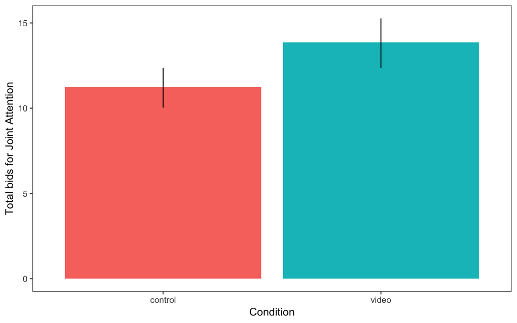

```r
save(d, file="Exp1_joint_attention_data.RData")
ms_bids <- d %>%
  group_by(Condition) %>%
  multi_boot_standard(col = "bids_tot")

ms_bids$Condition <- factor(ms_bids$Condition,
levels = c("con", "exp"),
labels = c("control", "video"))

ggplot(ms_bids, aes(x = Condition, y = mean, fill = Condition)) +
  geom_bar(stat="identity") +
  geom_linerange(aes(ymin = ci_lower, ymax = ci_upper),
             position = position_dodge(width = .9))+
  xlab("Condition") +
  ylab("Total bids for Joint Attention") +
  langcog::scale_colour_solarized()  +
  ggthemes::theme_few() +
  theme(legend.position="none")
```

Total episodes of joint attention.

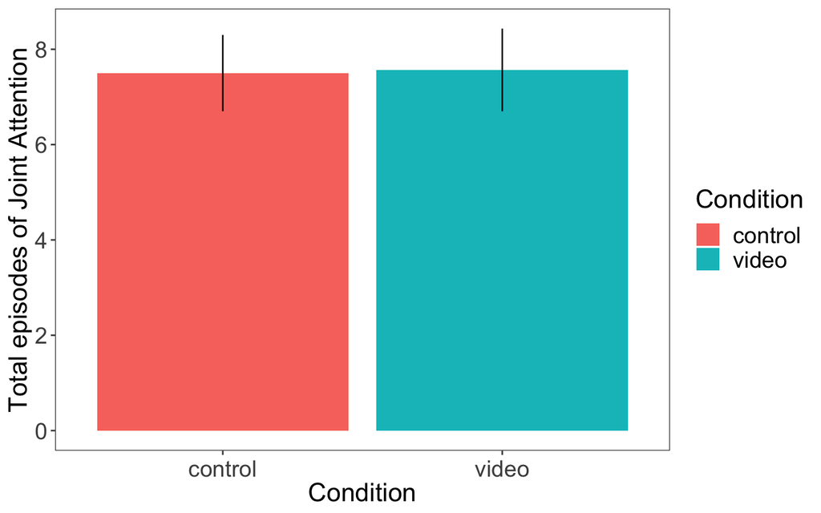

```r
ms_tja <- d %>%
  group_by(Condition) %>%
  multi_boot_standard(col = "total_ja")

ms_tja$Condition <- factor(ms_tja$Condition,
levels = c("con", "exp"),
labels = c("control", "video"))

ggplot(ms_tja, aes(x = Condition, y = mean, fill = Condition)) +
  geom_bar(stat="identity") +
  geom_linerange(aes(ymin = ci_lower, ymax = ci_upper),
             position = position_dodge(width = .9))+
  xlab("Condition") +
  ylab("Total episodes of Joint Attention") +
  langcog::scale_colour_solarized()  +
  ggthemes::theme_few() +
  theme(legend.title = element_text(size=18),
        legend.text = element_text(size=16),
        axis.text.x  = element_text(vjust=0.5, size=16),
        axis.title.x = element_text(size=18),
        axis.text.y  = element_text(vjust=0.5, size=16),
        axis.title.y = element_text(size=18))
```

Episodes of passive joint attention.

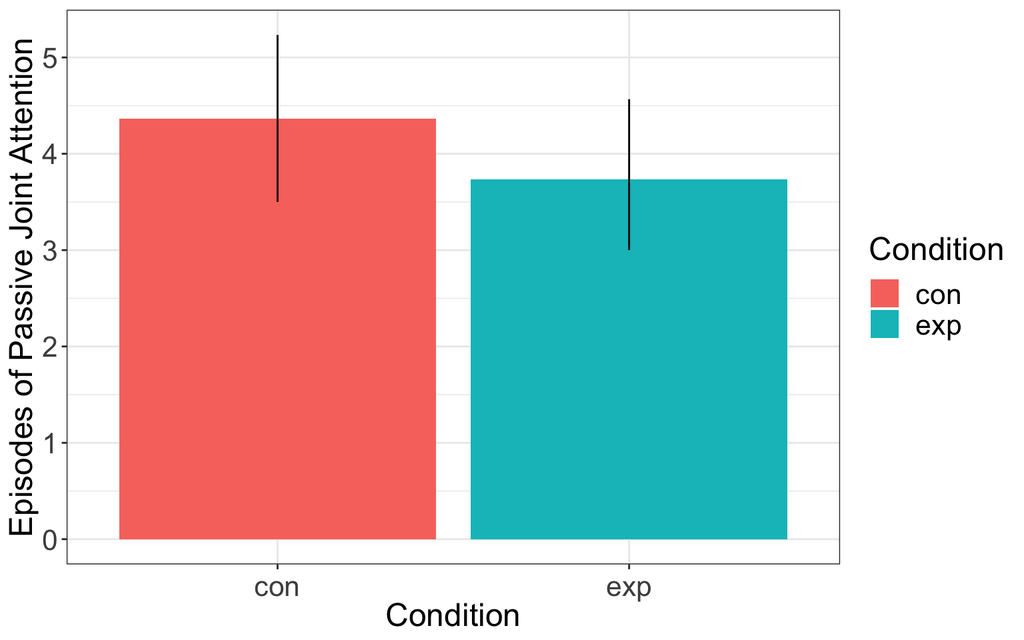

```r
ms_pja <- d %>%
  group_by(Condition) %>%
  multi_boot_standard(col = "pja")

ggplot(ms_pja, aes(x = Condition, y = mean, fill = Condition)) +
  geom_bar(stat="identity") +
  geom_linerange(aes(ymin = ci_lower, ymax = ci_upper),
             position = position_dodge(width = .9))+
  xlab("Condition") +
  ylab("Episodes of Passive Joint Attention")  +
  langcog::scale_colour_solarized() +
  theme(legend.title = element_text(size=18),
        legend.text = element_text(size=16),
        axis.text.x  = element_text(vjust=0.5, size=16),
        axis.title.x = element_text(size=18),
        axis.text.y  = element_text(vjust=0.5, size=16),
        axis.title.y = element_text(size=18))
```

Episodes of coordinated joint attention

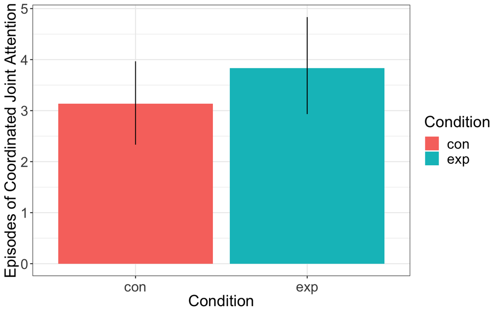

```r
ms_cja <- d %>%
  group_by(Condition) %>%
  multi_boot_standard(col = "cja")

ggplot(ms_cja, aes(x = Condition, y = mean, fill = Condition)) +
  geom_bar(stat="identity") +
  geom_linerange(aes(ymin = ci_lower, ymax = ci_upper),
             position = position_dodge(width = .9))+
  xlab("Condition") +
  ylab("Episodes of Coordinated Joint Attention")  +
  langcog::scale_colour_solarized()  +
  theme(legend.title = element_text(size=18),
        legend.text = element_text(size=16),
        axis.text.x  = element_text(vjust=0.5, size=16),
        axis.title.x = element_text(size=18),
        axis.text.y  = element_text(vjust=0.5, size=16),
        axis.title.y = element_text(size=18))
```

Total duration of passive joint attention.

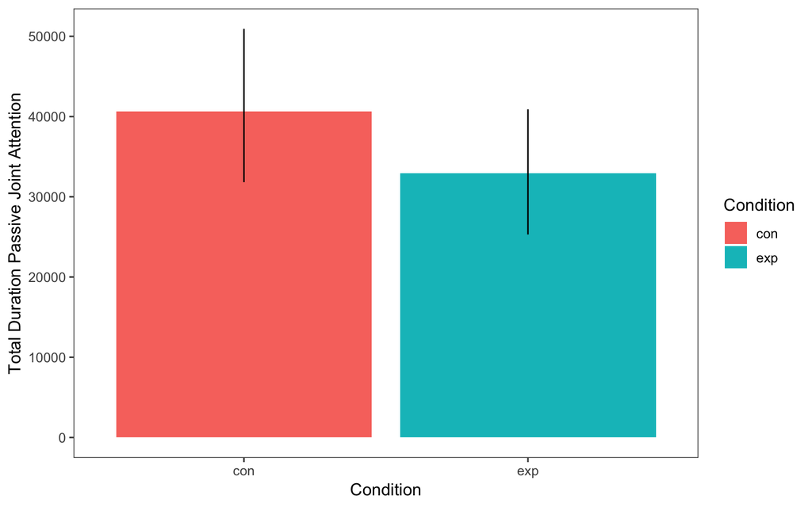

```r
ms_lpja <- d %>%
  filter(!is.na(Condition))%>%
  group_by(Condition) %>%
  multi_boot_standard(col = "pja_length")

ggplot(ms_lpja, aes(x = Condition, y = mean, fill = Condition)) +
  geom_bar(stat="identity") +
  geom_linerange(aes(ymin = ci_lower, ymax = ci_upper),
             position = position_dodge(width = .9))+
  xlab("Condition") +
  ylab("Total Duration Passive Joint Attention")  +
  langcog::scale_colour_solarized()  +
  ggthemes::theme_few()
```

Total duration of coordinated joint attention.

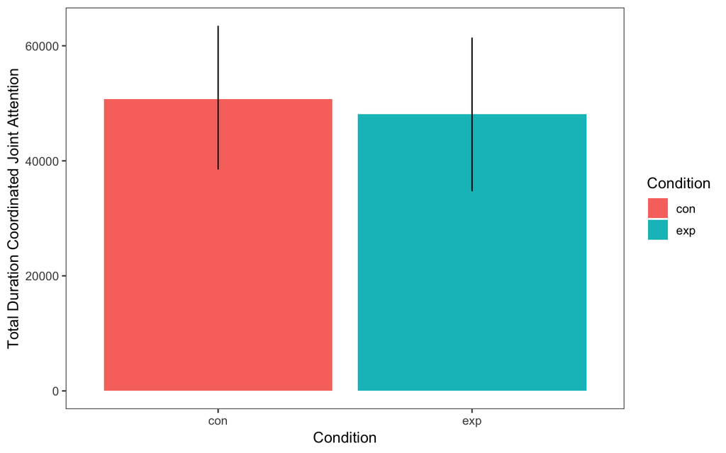

```r
ms_lcja <- d %>%
  filter(!is.na(Condition))%>%
  group_by(Condition) %>%
  multi_boot_standard(col = "cja_length")

ggplot(ms_lcja, aes(x = Condition, y = mean, fill = Condition)) +
  geom_bar(stat="identity") +
  geom_linerange(aes(ymin = ci_lower, ymax = ci_upper),
             position = position_dodge(width = .9))+
  xlab("Condition") +
  ylab("Total Duration Coordinated Joint Attention")  +
  langcog::scale_colour_solarized()  +
  ggthemes::theme_few()
```

##Demographics

###Child gender

Total bids by gender.

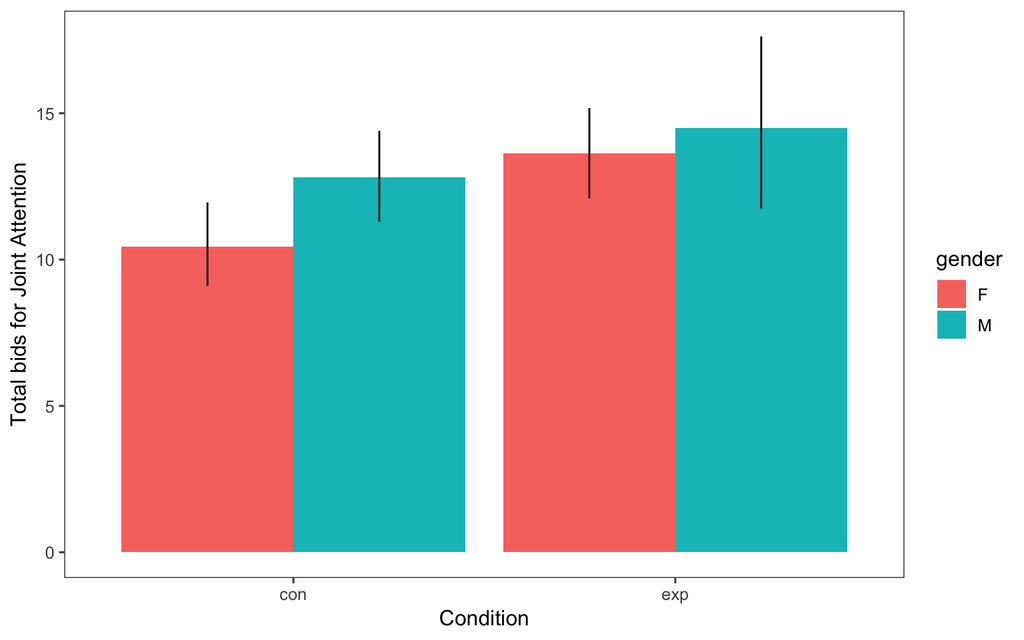

```r
# total bids
ms_bids <- d %>%
  group_by(Condition, gender) %>%
  multi_boot_standard(col = "bids_tot")

ggplot(ms_bids, aes(x = Condition, y = mean, fill=gender)) +
  geom_bar(stat="identity", position = "dodge") +
  geom_linerange(aes(ymin = ci_lower, ymax = ci_upper),
             position = position_dodge(width = .9))+
  xlab("Condition") +
  ylab("Total bids for Joint Attention")  +
  langcog::scale_colour_solarized()  +
  ggthemes::theme_few()
```

Total duration of passive joint attention by gender

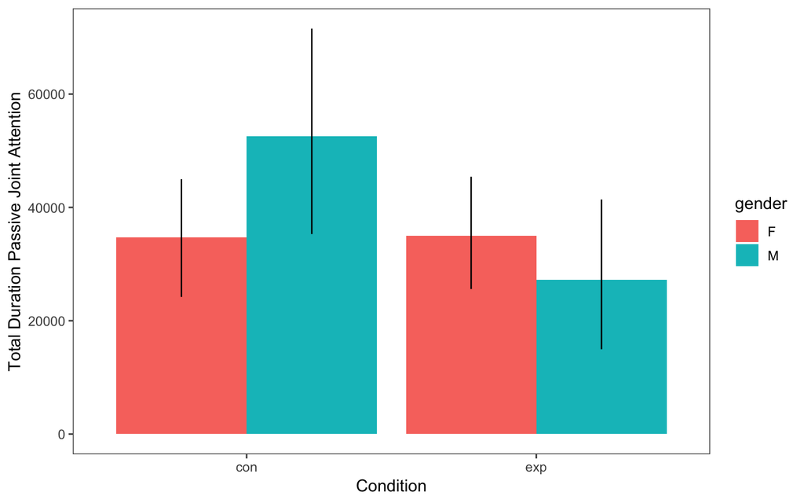

```r
ms_lpja <- d %>%
  filter(!is.na(Condition))%>%
  group_by(Condition, gender) %>%
  multi_boot_standard(col = "pja_length")

ggplot(ms_lpja, aes(x = Condition, y = mean, fill=gender)) +
  geom_bar(stat="identity", position = "dodge") +
  geom_linerange(aes(ymin = ci_lower, ymax = ci_upper),
             position = position_dodge(width = .9))+
  xlab("Condition") +
  ylab("Total Duration Passive Joint Attention")  +
  langcog::scale_colour_solarized()  +
  ggthemes::theme_few()
```

Total duration of coordinated joint attention by gender

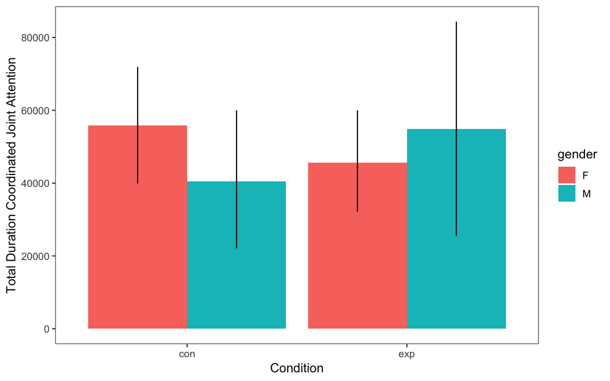

```r
ms_lcja <- d %>%
  filter(!is.na(Condition))%>%
  group_by(Condition, gender) %>%
  multi_boot_standard(col = "cja_length")

ggplot(ms_lcja, aes(x = Condition, y = mean, fill=gender)) +
  geom_bar(stat="identity", position = "dodge") +
  geom_linerange(aes(ymin = ci_lower, ymax = ci_upper),
             position = position_dodge(width = .9))+
  xlab("Condition") +
  ylab("Total Duration Coordinated Joint Attention")  +
  langcog::scale_colour_solarized()  +
  ggthemes::theme_few()
```

###Child age

Children were separated into 3 age groups: 6-12 months, 12-18 months, and 18-24 months.

Total bids by age.

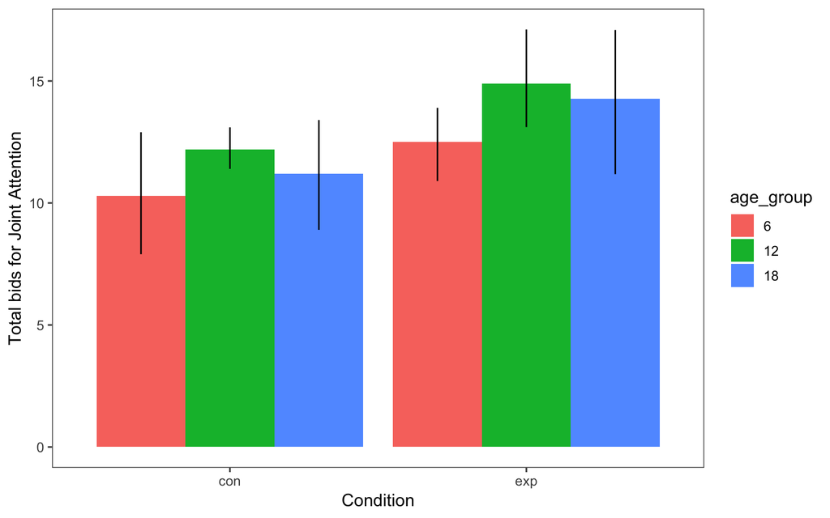

```r
# total bids
ms_bids <- d %>%
  group_by(Condition, age_group) %>%
  multi_boot_standard(col = "bids_tot")

ms_bids$age_group <- factor(ms_bids$age_group , levels = c("6","12", "18"))

ggplot(ms_bids, aes(x = Condition, y = mean, fill=age_group)) +
  geom_bar(stat="identity", position= "dodge") +
  geom_linerange(aes(ymin = ci_lower, ymax = ci_upper),
             position = position_dodge(width = .9))+
  xlab("Condition") +
  ylab("Total bids for Joint Attention")  +
  langcog::scale_colour_solarized()  +
  ggthemes::theme_few()
```

Total duration of passive joint attention by age

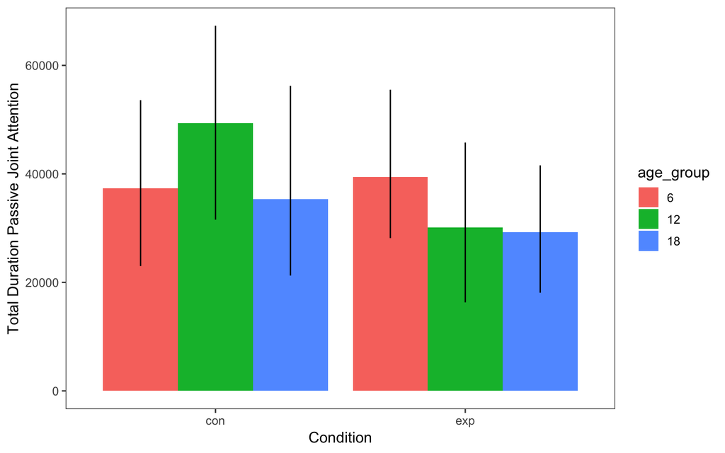

```r
ms_lpja <- d %>%
  filter(!is.na(Condition))%>%
  group_by(Condition, age_group) %>%
  multi_boot_standard(col = "pja_length")

ms_lpja$age_group <- factor(ms_lpja$age_group , levels = c("6","12", "18"))

ggplot(ms_lpja, aes(x = Condition, y = mean, fill = age_group)) +
  geom_bar(stat="identity", position = "dodge") +
  geom_linerange(aes(ymin = ci_lower, ymax = ci_upper),
             position = position_dodge(width = .9))+
  xlab("Condition") +
  ylab("Total Duration Passive Joint Attention")  +
  langcog::scale_colour_solarized()  +
  ggthemes::theme_few()
```

Total duration of coordinated joint attention by age

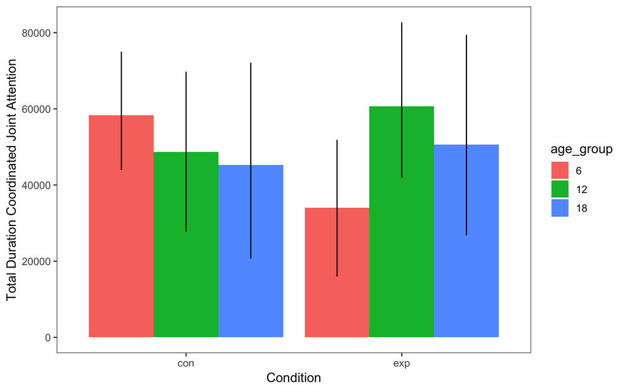

```r
ms_lcja <- d %>%
  filter(!is.na(Condition))%>%
  group_by(Condition, age_group) %>%
  multi_boot_standard(col = "cja_length")

ms_lcja$age_group <- factor(ms_lcja$age_group , levels = c("6","12", "18"))

ggplot(ms_lcja, aes(x = Condition, y = mean, fill = age_group)) +
  geom_bar(stat="identity", position = "dodge") +
  geom_linerange(aes(ymin = ci_lower, ymax = ci_upper),
             position = position_dodge(width = .9))+
  xlab("Condition") +
  ylab("Total Duration Coordinated Joint Attention")  +
  langcog::scale_colour_solarized()  +
  ggthemes::theme_few()
```

###Parenting attitudes and education

Do PAQ scores predict the number of bids for joint attention by parents?

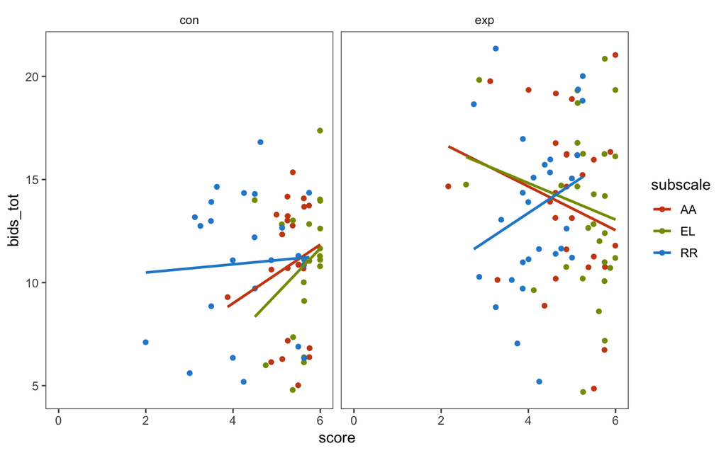

```r
d_plot <- d %>%
  gather("subscale","score", AA:RR)

ggplot(d_plot, aes(x = score, y = bids_tot, col = subscale)) +
  geom_jitter() +
  xlim(0,6) +
  geom_smooth(method="lm", se=FALSE)  +
  facet_wrap(~Condition)+
  ggthemes::theme_few() +
  langcog::scale_colour_solarized()
```

Does parent education predict the number of bids for joint attention by parents?

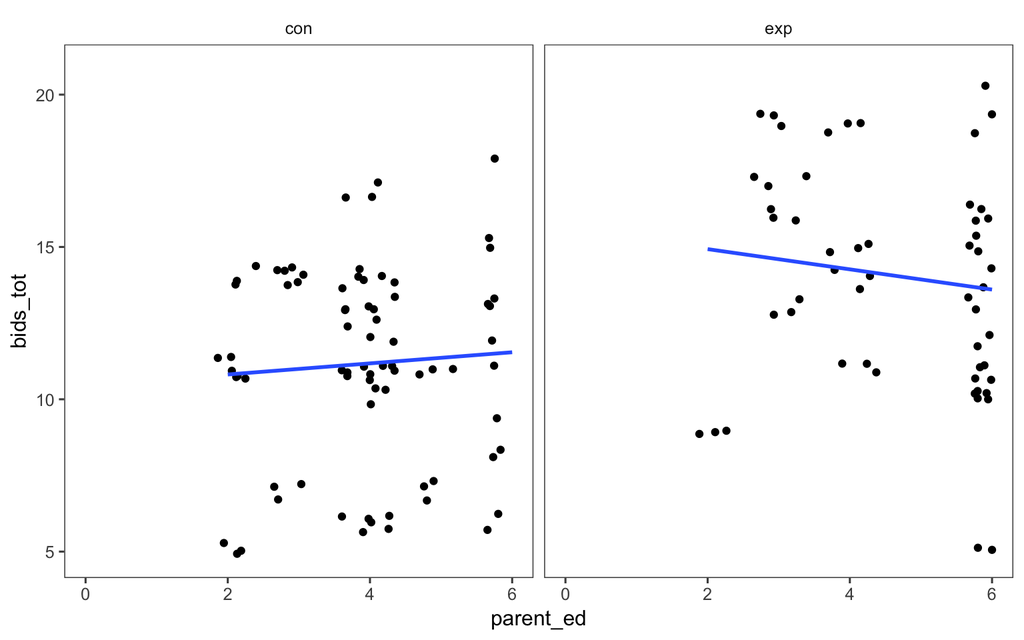

```r
d_plot <- d %>%
  gather("subscale","score", AA:RR)

ggplot(d_plot, aes(x = parent_ed, y = bids_tot)) +
  geom_jitter() +
  xlim(0,6) +
  geom_smooth(method="lm", se=FALSE)  +
  facet_wrap(~Condition)+
  ggthemes::theme_few() +
  langcog::scale_colour_solarized()
```

#Analysis

Is the duration of joint attention correlated with age in months?

```r
cormat <- d %>%
  select(age_months, pja_length, cja_length, total_lja)
rcorr(as.matrix(cormat))
```

```
##            age_months pja_length cja_length total_lja
## age_months       1.00      -0.13       0.01     -0.10
## pja_length      -0.13       1.00      -0.52      0.20
## cja_length       0.01      -0.52       1.00      0.73
## total_lja       -0.10       0.20       0.73      1.00
##
## n= 60
##
##
## P
##            age_months pja_length cja_length total_lja
## age_months            0.3114     0.9539     0.4606
## pja_length 0.3114                0.0000     0.1325
## cja_length 0.9539     0.0000                0.0000
## total_lja  0.4606     0.1325     0.0000
```

Mixed effects models.

Prepare data.

```r
lmer_data <- d %>%
  filter(!is.na(AA), !is.na(EL), !is.na(RR))%>%
  mutate(Condition = factor(Condition),
         bids_tot = as.numeric(bids_tot),
         EL = as.numeric(langcog::scale(EL, scale=FALSE)),
         AA = as.numeric(langcog::scale(AA, scale=FALSE)),
         RR = as.numeric(langcog::scale(RR, scale=FALSE)),
         age = as.numeric(langcog::scale(age, scale=FALSE)),
         gender = as.factor(gender),
         Video = as.factor(Video))
```

Total number of bids

```r
maximal_mod <- lmer(bids_tot ~ Condition *  EL  + Condition * AA + Condition * RR + age + gender + parent_ed +
                           (1| Video),
                         data = lmer_data)
summary(maximal_mod)
```

```
## Linear mixed model fit by REML. t-tests use Satterthwaite's method [
## lmerModLmerTest]
## Formula: bids_tot ~ Condition * EL + Condition * AA + Condition * RR +
##     age + gender + parent_ed + (1 | Video)
##    Data: lmer_data
##
## REML criterion at convergence: 260
##
## Scaled residuals:
##      Min       1Q   Median       3Q      Max
## -2.05417 -0.68228  0.01915  0.47428  2.14035
##
## Random effects:
##  Groups   Name        Variance Std.Dev.
##  Video    (Intercept)  0.9151  0.9566
##  Residual             12.0599  3.4727
## Number of obs: 54, groups:  Video, 6
##
## Fixed effects:
##                 Estimate Std. Error       df t value Pr(>|t|)
## (Intercept)     10.17036    2.15328 33.61162   4.723 4.01e-05 ***
## Conditionexp     3.51386    1.19239 40.31490   2.947  0.00531 **
## EL               2.19022    2.00945 42.48398   1.090  0.28187
## AA               1.56335    1.65507 42.96309   0.945  0.35015
## RR              -0.03157    0.84602 41.38312  -0.037  0.97041
## age              0.84222    1.47638  6.67895   0.570  0.58703
## genderM          2.28867    1.15674 41.53910   1.979  0.05452 .
## parent_ed       -0.15227    0.44646 41.70326  -0.341  0.73478
## Conditionexp:EL -1.90173    2.48945 42.95489  -0.764  0.44909
## Conditionexp:AA -2.91173    2.12242 42.87172  -1.372  0.17723
## Conditionexp:RR  1.22631    1.22799 40.93901   0.999  0.32384
## ---
## Signif. codes:  0 '***' 0.001 '**' 0.01 '*' 0.05 '.' 0.1 ' ' 1
##
## Correlation of Fixed Effects:
##             (Intr) Cndtnx EL     AA     RR     age    gendrM prnt_d Cnd:EL
## Conditionxp  0.004
## EL          -0.027  0.362
## AA          -0.299  0.258 -0.095
## RR          -0.269 -0.235 -0.457  0.007
## age          0.121  0.034  0.113 -0.096 -0.007
## genderM     -0.090  0.046 -0.083  0.169  0.155 -0.134
## parent_ed   -0.877 -0.357 -0.147  0.114  0.344 -0.109 -0.088
## Condtnxp:EL -0.105 -0.324 -0.848  0.085  0.426 -0.130  0.077  0.263
## Condtnxp:AA  0.402 -0.111  0.124 -0.823 -0.085  0.154 -0.210 -0.264 -0.339
## Condtnxp:RR  0.064  0.180  0.289  0.018 -0.634 -0.046 -0.040 -0.113 -0.204
##             Cnd:AA
## Conditionxp
## EL
## AA
## RR
## age
## genderM
## parent_ed
## Condtnxp:EL
## Condtnxp:AA
## Condtnxp:RR  0.005
```

Episodes of coordinated joint attention.

```r
maximal_mod <- lmer(cja ~ Condition *  EL  + Condition * AA + Condition * RR  + age + gender + parent_ed +
                           (1| Video),
                         data = lmer_data)
summary(maximal_mod)
```

```
## Linear mixed model fit by REML. t-tests use Satterthwaite's method [
## lmerModLmerTest]
## Formula: cja ~ Condition * EL + Condition * AA + Condition * RR + age +
##     gender + parent_ed + (1 | Video)
##    Data: lmer_data
##
## REML criterion at convergence: 237.1
##
## Scaled residuals:
##      Min       1Q   Median       3Q      Max
## -1.79034 -0.57112 -0.04321  0.51055  2.42451
##
## Random effects:
##  Groups   Name        Variance Std.Dev.
##  Video    (Intercept) 0.4427   0.6654
##  Residual             7.1402   2.6721
## Number of obs: 54, groups:  Video, 6
##
## Fixed effects:
##                 Estimate Std. Error      df t value Pr(>|t|)
## (Intercept)       1.3562     1.6421 33.4994   0.826    0.415
## Conditionexp      0.3116     0.9170 40.5195   0.340    0.736
## EL                0.1842     1.5428 42.5963   0.119    0.906
## AA               -0.6909     1.2696 42.9931  -0.544    0.589
## RR                0.8296     0.6502 41.5762   1.276    0.209
## age               1.2926     1.1047  6.9378   1.170    0.281
## genderM          -0.2328     0.8889 41.7535  -0.262    0.795
## parent_ed         0.4200     0.3417 41.3381   1.229    0.226
## Conditionexp:EL  -0.3396     1.9084 42.8768  -0.178    0.860
## Conditionexp:AA   0.9842     1.6266 42.7529   0.605    0.548
## Conditionexp:RR  -0.4696     0.9440 41.2003  -0.497    0.621
##
## Correlation of Fixed Effects:
##             (Intr) Cndtnx EL     AA     RR     age    gendrM prnt_d Cnd:EL
## Conditionxp  0.003
## EL          -0.027  0.361
## AA          -0.296  0.260 -0.095
## RR          -0.268 -0.234 -0.456  0.005
## age          0.125  0.041  0.126 -0.102 -0.013
## genderM     -0.093  0.046 -0.083  0.170  0.156 -0.141
## parent_ed   -0.878 -0.359 -0.147  0.109  0.342 -0.115 -0.086
## Condtnxp:EL -0.106 -0.324 -0.848  0.087  0.426 -0.141  0.078  0.264
## Condtnxp:AA  0.399 -0.113  0.123 -0.822 -0.082  0.159 -0.211 -0.259 -0.340
## Condtnxp:RR  0.064  0.179  0.289  0.020 -0.635 -0.045 -0.041 -0.113 -0.203
##             Cnd:AA
## Conditionxp
## EL
## AA
## RR
## age
## genderM
## parent_ed
## Condtnxp:EL
## Condtnxp:AA
## Condtnxp:RR  0.003
```

Episodes of passive joint attention.

```r
maximal_mod <- lmer(pja ~ Condition *  EL  + Condition * AA + Condition * RR  + age + gender + parent_ed +
                           (1| Video),
                         data = lmer_data)
summary(maximal_mod)
```

```
## Linear mixed model fit by REML. t-tests use Satterthwaite's method [
## lmerModLmerTest]
## Formula: pja ~ Condition * EL + Condition * AA + Condition * RR + age +
##     gender + parent_ed + (1 | Video)
##    Data: lmer_data
##
## REML criterion at convergence: 225.1
##
## Scaled residuals:
##      Min       1Q   Median       3Q      Max
## -1.48520 -0.71679  0.05066  0.52895  2.60949
##
## Random effects:
##  Groups   Name        Variance Std.Dev.
##  Video    (Intercept) 0.1991   0.4462
##  Residual             5.4660   2.3379
## Number of obs: 54, groups:  Video, 6
##
## Fixed effects:
##                 Estimate Std. Error       df t value Pr(>|t|)
## (Intercept)      5.74376    1.40946 32.34329   4.075 0.000279 ***
## Conditionexp    -0.03461    0.80136 40.69553  -0.043 0.965760
## EL               0.71069    1.34355 42.76493   0.529 0.599564
## AA               0.64871    1.10338 42.98232   0.588 0.559652
## RR              -1.06565    0.56736 41.81175  -1.878 0.067331 .
## age             -0.09116    0.91181  6.92532  -0.100 0.923193
## genderM          1.09259    0.77538 42.03971   1.409 0.166158
## parent_ed       -0.44175    0.29546 40.25714  -1.495 0.142673
## Conditionexp:EL -0.60046    1.65571 42.54478  -0.363 0.718652
## Conditionexp:AA -0.97980    1.41056 42.34393  -0.695 0.491086
## Conditionexp:RR  1.83133    0.82414 41.53927   2.222 0.031778 *
## ---
## Signif. codes:  0 '***' 0.001 '**' 0.01 '*' 0.05 '.' 0.1 ' ' 1
##
## Correlation of Fixed Effects:
##             (Intr) Cndtnx EL     AA     RR     age    gendrM prnt_d Cnd:EL
## Conditionxp  0.002
## EL          -0.027  0.360
## AA          -0.289  0.265 -0.096
## RR          -0.264 -0.233 -0.456 -0.001
## age          0.134  0.056  0.151 -0.114 -0.025
## genderM     -0.101  0.048 -0.083  0.173  0.158 -0.155
## parent_ed   -0.880 -0.362 -0.149  0.098  0.337 -0.128 -0.082
## Condtnxp:EL -0.108 -0.323 -0.847  0.090  0.425 -0.165  0.079  0.267
## Condtnxp:AA  0.393 -0.117  0.122 -0.821 -0.075  0.171 -0.215 -0.248 -0.343
## Condtnxp:RR  0.063  0.178  0.286  0.025 -0.636 -0.043 -0.042 -0.112 -0.201
##             Cnd:AA
## Conditionxp
## EL
## AA
## RR
## age
## genderM
## parent_ed
## Condtnxp:EL
## Condtnxp:AA
## Condtnxp:RR -0.001
```

Total duration of passive joint attention.

```r
maximal_mod <- lmer(pja_length ~ Condition *  EL  + Condition * AA + Condition * RR  + age + gender + parent_ed +
                           (1| Video),
                         data = lmer_data)
summary(maximal_mod)
```

```
## Linear mixed model fit by REML. t-tests use Satterthwaite's method [
## lmerModLmerTest]
## Formula: pja_length ~ Condition * EL + Condition * AA + Condition * RR +
##     age + gender + parent_ed + (1 | Video)
##    Data: lmer_data
##
## REML criterion at convergence: 1027.7
##
## Scaled residuals:
##     Min      1Q  Median      3Q     Max
## -1.2657 -0.7103 -0.1369  0.6519  2.5372
##
## Random effects:
##  Groups   Name        Variance  Std.Dev.
##  Video    (Intercept)  51951682  7208
##  Residual             685084736 26174
## Number of obs: 54, groups:  Video, 6
##
## Fixed effects:
##                  Estimate Std. Error        df t value Pr(>|t|)
## (Intercept)     56023.250  16228.868    33.785   3.452  0.00151 **
## Conditionexp    -3756.090   8987.077    40.375  -0.418  0.67820
## EL              -2578.997  15145.184    42.496  -0.170  0.86559
## AA               8184.192  12474.179    42.964   0.656  0.51526
## RR              -5489.279   6376.482    41.421  -0.861  0.39427
## age             -9188.057  11126.423     6.816  -0.826  0.43687
## genderM         12284.411   8718.345    41.573   1.409  0.16626
## parent_ed       -4498.358   3364.963    41.732  -1.337  0.18852
## Conditionexp:EL -3199.993  18762.813    42.956  -0.171  0.86538
## Conditionexp:AA -7952.597  15996.527    42.874  -0.497  0.62163
## Conditionexp:RR 10381.442   9255.372    40.986   1.122  0.26853
## ---
## Signif. codes:  0 '***' 0.001 '**' 0.01 '*' 0.05 '.' 0.1 ' ' 1
##
## Correlation of Fixed Effects:
##             (Intr) Cndtnx EL     AA     RR     age    gendrM prnt_d Cnd:EL
## Conditionxp  0.004
## EL          -0.027  0.362
## AA          -0.299  0.258 -0.095
## RR          -0.269 -0.235 -0.457  0.007
## age          0.121  0.034  0.113 -0.096 -0.007
## genderM     -0.090  0.046 -0.083  0.169  0.155 -0.134
## parent_ed   -0.877 -0.357 -0.147  0.114  0.344 -0.109 -0.088
## Condtnxp:EL -0.105 -0.324 -0.848  0.085  0.426 -0.130  0.077  0.263
## Condtnxp:AA  0.402 -0.111  0.124 -0.823 -0.085  0.154 -0.210 -0.264 -0.339
## Condtnxp:RR  0.064  0.180  0.289  0.018 -0.634 -0.046 -0.040 -0.113 -0.204
##             Cnd:AA
## Conditionxp
## EL
## AA
## RR
## age
## genderM
## parent_ed
## Condtnxp:EL
## Condtnxp:AA
## Condtnxp:RR  0.005
```

Total duration of coordinated joint attention.

```r
maximal_mod <- lmer(cja_length ~ Condition *  EL  + Condition * AA + Condition * RR  + age + gender + parent_ed +
                           (1| Video),
                         data = lmer_data)
summary(maximal_mod)
```

```
## Linear mixed model fit by REML. t-tests use Satterthwaite's method [
## lmerModLmerTest]
## Formula: cja_length ~ Condition * EL + Condition * AA + Condition * RR +
##     age + gender + parent_ed + (1 | Video)
##    Data: lmer_data
##
## REML criterion at convergence: 1063
##
## Scaled residuals:
##      Min       1Q   Median       3Q      Max
## -1.51487 -0.68595 -0.08384  0.46650  2.27459
##
## Random effects:
##  Groups   Name        Variance  Std.Dev.
##  Video    (Intercept) 0.000e+00     0
##  Residual             1.622e+09 40278
## Number of obs: 54, groups:  Video, 6
##
## Fixed effects:
##                 Estimate Std. Error     df t value Pr(>|t|)
## (Intercept)        16721      23411     43   0.714   0.4790
## Conditionexp       -8469      13777     43  -0.615   0.5420
## EL                   724      22931     43   0.032   0.9750
## AA                 -1491      18756     43  -0.080   0.9370
## RR                  7665       9724     43   0.788   0.4349
## age                -2401      14158     43  -0.170   0.8662
## genderM           -10457      13278     43  -0.788   0.4352
## parent_ed           8531       4968     43   1.717   0.0932 .
## Conditionexp:EL    -1359      28025     43  -0.048   0.9615
## Conditionexp:AA     7584      23861     43   0.318   0.7521
## Conditionexp:RR     1616      14133     43   0.114   0.9095
## ---
## Signif. codes:  0 '***' 0.001 '**' 0.01 '*' 0.05 '.' 0.1 ' ' 1
##
## Correlation of Fixed Effects:
##             (Intr) Cndtnx EL     AA     RR     age    gendrM prnt_d Cnd:EL
## Conditionxp  0.000
## EL          -0.027  0.356
## AA          -0.274  0.273 -0.098
## RR          -0.256 -0.231 -0.455 -0.011
## age          0.154  0.081  0.198 -0.137 -0.046
## genderM     -0.117  0.050 -0.085  0.179  0.162 -0.179
## parent_ed   -0.882 -0.368 -0.151  0.075  0.328 -0.153 -0.073
## Condtnxp:EL -0.112 -0.322 -0.846  0.098  0.424 -0.210  0.083  0.272
## Condtnxp:AA  0.378 -0.126  0.118 -0.820 -0.061  0.193 -0.221 -0.224 -0.348
## Condtnxp:RR  0.062  0.175  0.282  0.034 -0.638 -0.041 -0.045 -0.111 -0.198
##             Cnd:AA
## Conditionxp
## EL
## AA
## RR
## age
## genderM
## parent_ed
## Condtnxp:EL
## Condtnxp:AA
## Condtnxp:RR -0.011
## convergence code: 0
## boundary (singular) fit: see ?isSingular
```

#Conclusions

There is a main effect of condition on total bids for joint attention. Parents in the experimental condition (i.e., those who saw a video demonstrating an activity) made a greater number of bids for joint attention with their child.

There was no effect of condition on the number of episodes of either passive or coordinated joint attention, or the duration of these episodes.

While the electronically-delivered parenting advice increased the number of bids for joint attention by parents, it did not significantly effect the number or duration of episodes of joint attention. One possibility is that child variables had a comparatively larger impact on the attainment of joint attention.